# Michael Ellison | Eisha Ahmed | Rachita Sinha

Crime rates are known to vary across geographic locations and the underlying cause of this variation are many and disputed. Of all these causes, could employment be a strong one? Do higher employment rates increase the crime rate or decrease it? Does time have any sort of factor in either of these topics? These are some of the questions we hope to explore in this tutorial.

Our tutorial serves to analyze the potential relationship between the rate of employment and the average crime rate. We want to analyze this question in a small controllable group since attempting to analyze this relationship across the whole country may have many other factors that affect both employment and crime rates. We have chosen to focus our study within the state of Maryland. While different locations could provide different results we hope that starting with one area could give some useful starting insight. We hope to take our data for crime rates and employment and compare and contrast them to provide a coherent and cohesive study of how the two may relate to each other.

This tutorial utilizes Python 3 and its associated libraries as well as datasets containing employment rate and crime rate information in the state of Maryland. Becoming familiar with these libraries and their associated function will be useful to follow along with this tutorial. These libraries include Pandas, NumPy, Matplotlib, Statsmodels, and Scikit-learn.

> Links to the Python library documentations:
> - https://pandas.pydata.org/pandas-docs/stable/
> - https://numpy.org/doc/
> - https://matplotlib.org/
> - https://www.statsmodels.org/stable/index.html
> - https://scikit-learn.org/stable/

> Links to the relevant datasets:
> - https://opendata.maryland.gov/api/views/hyg2-hy98/rows.csv?accessType=DOWNLOAD
> - https://opendata.maryland.gov/api/views/ub9y-b3wy/rows.csv?accessType=DOWNLOAD

#### **Relevant Geographical Area for Analysis: Maryland**

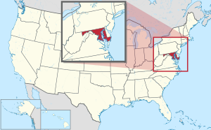

# Data Collection

#### To analyze this relationship we will utilize Python 3 along with the following libraries:

- Pandas
- Numpy
- Matplotlib
- Statsmodels
- Sklearn

```python
import pandas as pd
import numpy as np
import matplotlib.pyplot as plt
import statsmodels.api as sm
from sklearn import linear_model

import warnings
warnings.filterwarnings("ignore")
```

## Data Retrieval

```python
crime = "https://opendata.maryland.gov/api/views/hyg2-hy98/rows.csv?accessType=DOWNLOAD"
employment = "https://opendata.maryland.gov/api/views/ub9y-b3wy/rows.csv?accessType=DOWNLOAD"
crimeDF = pd.read_csv(crime)
employmentDF  = pd.read_csv(employment)
```

### Dateset Description: Crime

```python
crimeDF.head()
```

|  | JURISDICTION | YEAR | POPULATION | MURDER | RAPE | ROBBERY | AGG. ASSAULT | B & E | LARCENY THEFT | M/V THEFT | ... | B & E PER 100,000 PEOPLE | LARCENY THEFT PER 100,000 PEOPLE | M/V THEFT PER 100,000 PEOPLE | MURDER RATE PERCENT CHANGE PER 100,000 PEOPLE | RAPE RATE PERCENT CHANGE PER 100,000 PEOPLE | ROBBERY RATE PERCENT CHANGE PER 100,000 PEOPLE | AGG. ASSAULT RATE PERCENT CHANGE PER 100,000 PEOPLE | B & E RATE PERCENT CHANGE PER 100,000 PEOPLE | LARCENY THEFT RATE PERCENT CHANGE PER 100,000 PEOPLE | M/V THEFT RATE PERCENT CHANGE PER 100,000 PEOPLE |
| --- | --- | --- | --- | --- | --- | --- | --- | --- | --- | --- | --- | --- | --- | --- | --- | --- | --- | --- | --- | --- | --- |
| 0 | Maryland | 1975 | 4098000 | 435 | 1288 | 14104 | 13251 | 57936 | 134001 | 21192 | ... | 1413.8 | 3269.9 | 517.1 | NaN | NaN | NaN | NaN | NaN | NaN | NaN |
| 1 | Maryland | 1976 | 4144000 | 352 | 1327 | 12247 | 12322 | 56351 | 134337 | 17772 | ... | 1359.8 | 3241.7 | 428.9 | -20.0 | 1.9 | -14.1 | -8.0 | -3.8 | -0.9 | -17.1 |
| 2 | Maryland | 1977 | 4139000 | 333 | 1439 | 12088 | 14856 | 57938 | 131516 | 17732 | ... | 1399.8 | 3177.5 | 428.4 | -5.3 | 8.6 | -1.2 | 20.7 | 2.9 | -2.0 | -0.1 |
| 3 | Maryland | 1978 | 4143000 | 338 | 1476 | 12828 | 15686 | 58901 | 134012 | 17599 | ... | 1421.7 | 3234.7 | 424.8 | 1.4 | 2.5 | 6.0 | 5.5 | 1.6 | 1.8 | -0.8 |
| 4 | Maryland | 1979 | 4149000 | 406 | 1628 | 13745 | 17337 | 62657 | 145278 | 20217 | ... | 1510.2 | 3501.5 | 487.3 | 19.9 | 10.1 | 7.0 | 10.4 | 6.2 | 8.2 | 14.7 |

5 rows × 38 columns

### Dataset Description: Employment

This dataset portrays employment information in the state of Maryland from 2007 to 2019. It gives the exact DateTime in addition to the relevant year. It provides the non-institutional population as well as a total for the labor force. Additionally, the dataset provides information regarding the number within the population that is both employed and unemployed. For each of these descriptors, a rate compared to the total population is given. The relevant columns in this dataset are the DateTime, population, labor force, labor force rate, employment rate, and unemployment rate. In the out tutorial, we will be focusing predominantly on the unemployment rate.

```python
employmentDF.head()
```

|  | Date | Year | Month | Date Label | Civilian Non-institutional Population | Civilian Labor Force | Labor Force Participation Rate | Employed | Employment Rate | Unemployed | Unemployment Rate |
| --- | --- | --- | --- | --- | --- | --- | --- | --- | --- | --- | --- |
| 0 | 01/01/2007 12:00:00 AM | 2007 | 1 | Jan 2007 | 4312014 | 2973568 | 69.0 | 2864870 | 66.4 | 108698 | 3.7 |
| 1 | 02/01/2007 12:00:00 AM | 2007 | 2 | Feb 2007 | 4314108 | 2970937 | 68.9 | 2864666 | 66.4 | 106271 | 3.6 |
| 2 | 03/01/2007 12:00:00 AM | 2007 | 3 | Mar 2007 | 4316235 | 2968053 | 68.8 | 2863964 | 66.4 | 104089 | 3.5 |
| 3 | 04/01/2007 12:00:00 AM | 2007 | 4 | Apr 2007 | 4318781 | 2965743 | 68.7 | 2863381 | 66.3 | 102362 | 3.5 |
| 4 | 05/01/2007 12:00:00 AM | 2007 | 5 | May 2007 | 4321081 | 2964741 | 68.6 | 2863307 | 66.3 | 101434 | 3.4 |

### Modifying the Datasets

Both datasets have approximately 12 years of overlap. This overlap will allow us to have an average and variance per year for the variables crime rate and unemployment rate. Here we reduce our datasets so that they provide information over the same span of years. Doing so will also enable us to perform a regression analysis later on in the tutorial.

```python
# Modifying datasets so that they both start in 2007 and end in 2019
employmentDF = employmentDF[employmentDF["Year"] >= 2007]
crimeDF = crimeDF[crimeDF["YEAR"] >= 2007]
```

#### Crime DataFrame

```python
crimeDF.head()
```

|  | JURISDICTION | YEAR | POPULATION | MURDER | RAPE | ROBBERY | AGG. ASSAULT | B & E | LARCENY THEFT | M/V THEFT | ... | B & E PER 100,000 PEOPLE | LARCENY THEFT PER 100,000 PEOPLE | M/V THEFT PER 100,000 PEOPLE | MURDER RATE PERCENT CHANGE PER 100,000 PEOPLE | RAPE RATE PERCENT CHANGE PER 100,000 PEOPLE | ROBBERY RATE PERCENT CHANGE PER 100,000 PEOPLE | AGG. ASSAULT RATE PERCENT CHANGE PER 100,000 PEOPLE | B & E RATE PERCENT CHANGE PER 100,000 PEOPLE | LARCENY THEFT RATE PERCENT CHANGE PER 100,000 PEOPLE | M/V THEFT RATE PERCENT CHANGE PER 100,000 PEOPLE |
| --- | --- | --- | --- | --- | --- | --- | --- | --- | --- | --- | --- | --- | --- | --- | --- | --- | --- | --- | --- | --- | --- |
| 32 | Maryland | 2007 | 5618344 | 554 | 1179 | 13258 | 21074 | 37095 | 127307 | 28393 | ... | 660.2 | 2265.9 | 505.4 | 1.2 | 0.0 | -7.8 | -4.3 | -1.0 | -0.2 | -7.0 |
| 33 | Maryland | 2008 | 5633597 | 493 | 1127 | 13203 | 20571 | 38849 | 133983 | 25340 | ... | 689.6 | 2378.3 | 449.8 | -11.3 | -4.7 | -0.7 | -2.7 | 4.4 | 5.0 | -11.0 |
| 34 | Maryland | 2009 | 5699478 | 440 | 1156 | 12007 | 20022 | 36905 | 125771 | 19619 | ... | 647.5 | 2206.7 | 344.2 | -11.8 | 1.4 | -10.1 | -3.8 | -6.1 | -7.2 | -23.5 |
| 35 | Maryland | 2010 | 5773552 | 425 | 1228 | 11053 | 18898 | 36700 | 118583 | 18029 | ... | 635.7 | 2053.9 | 312.3 | -4.6 | 4.9 | -9.1 | -6.8 | -1.8 | -6.9 | -9.3 |
| 36 | Maryland | 2011 | 5828289 | 398 | 1196 | 10338 | 16866 | 35781 | 114871 | 16067 | ... | 613.9 | 1970.9 | 275.7 | -7.2 | -3.5 | -7.3 | -11.6 | -3.4 | -4.0 | -11.7 |

5 rows × 38 columns

#### Employment DataFrame

```python
employmentDF.head()
```

|  | Date | Year | Month | Date Label | Civilian Non-institutional Population | Civilian Labor Force | Labor Force Participation Rate | Employed | Employment Rate | Unemployed | Unemployment Rate |
| --- | --- | --- | --- | --- | --- | --- | --- | --- | --- | --- | --- |
| 0 | 01/01/2007 12:00:00 AM | 2007 | 1 | Jan 2007 | 4312014 | 2973568 | 69.0 | 2864870 | 66.4 | 108698 | 3.7 |
| 1 | 02/01/2007 12:00:00 AM | 2007 | 2 | Feb 2007 | 4314108 | 2970937 | 68.9 | 2864666 | 66.4 | 106271 | 3.6 |
| 2 | 03/01/2007 12:00:00 AM | 2007 | 3 | Mar 2007 | 4316235 | 2968053 | 68.8 | 2863964 | 66.4 | 104089 | 3.5 |
| 3 | 04/01/2007 12:00:00 AM | 2007 | 4 | Apr 2007 | 4318781 | 2965743 | 68.7 | 2863381 | 66.3 | 102362 | 3.5 |
| 4 | 05/01/2007 12:00:00 AM | 2007 | 5 | May 2007 | 4321081 | 2964741 | 68.6 | 2863307 | 66.3 | 101434 | 3.4 |

### Unemployment Dataframe

In this step our data from the employment dataframe has been parsed to make a new dataframe labeled *employmentNew*. This new dataframe contains 2 main pieces of information, the average unemployment rate and the unemployment rate variance between 2007 and 2019, labeled *UnemploymentRateAverage* and *UnemploymentRateVariance* respectively. This new dataframe will be used to analyze the potential relationship between unemployment rate and crime rate.

```python
# Making new dataframe that will present the current year, average unemployment rate for
# that year, and the unemployment rate variance for that year
temp = []

for year in employmentDF["Year"].unique():
  tempDF = employmentDF[employmentDF["Year"]== year]
  temp.append([year, np.mean(tempDF["Unemployment Rate"]), np.var(tempDF["Unemployment Rate"])])

employmentNew = pd.DataFrame(data=temp, columns=["Year","UnemploymentRateAverage","UnemploymentRateVariance"])
employmentNew = employmentNew.set_index(["Year"])
employmentNew.head()
```

| Year | UnemploymentRateAverage | UnemploymentRateVariance |
| --- | --- | --- |
| 2007 | 3.450000 | 0.010833 |
| 2008 | 4.250000 | 0.607500 |
| 2009 | 7.016667 | 0.194722 |
| 2010 | 7.650000 | 0.010833 |
| 2011 | 7.250000 | 0.010833 |

#### Data Curation: Modifying the crime dataframe to include only relevant information

```python
crimePercentDF = crimeDF
crimeDF = crimeDF.drop(['JURISDICTION',  'POPULATION', 'MURDER', 'RAPE', 'ROBBERY',
       'AGG. ASSAULT', 'B & E', 'LARCENY THEFT', 'M/V THEFT', 'GRAND TOTAL',
       'PERCENT CHANGE', 'VIOLENT CRIME TOTAL', 'VIOLENT CRIME PERCENT',
       'VIOLENT CRIME PERCENT CHANGE', 'PROPERTY CRIME TOTALS',
       'PROPERTY CRIME PERCENT', 'PROPERTY CRIME PERCENT CHANGE',
       'OVERALL PERCENT CHANGE PER 100,000 PEOPLE',
       'VIOLENT CRIME RATE PERCENT CHANGE PER 100,000 PEOPLE',
       'PROPERTY CRIME RATE PERCENT CHANGE PER 100,000 PEOPLE',
       'MURDER  RATE PERCENT CHANGE PER 100,000 PEOPLE',
       'RAPE RATE PERCENT CHANGE PER 100,000 PEOPLE',
       'ROBBERY RATE PERCENT CHANGE PER 100,000 PEOPLE',
       'AGG. ASSAULT  RATE PERCENT CHANGE PER 100,000 PEOPLE',
       'B & E RATE PERCENT CHANGE PER 100,000 PEOPLE',
       'LARCENY THEFT  RATE PERCENT CHANGE PER 100,000 PEOPLE',
       'M/V THEFT  RATE PERCENT CHANGE PER 100,000 PEOPLE'], axis = 1)
crimeDF = crimeDF.set_index(["YEAR"])
crimeDF.head()
```

| YEAR | OVERALL CRIME RATE PER 100,000 PEOPLE | VIOLENT CRIME RATE PER 100,000 PEOPLE | PROPERTY CRIME RATE PER 100,000 PEOPLE | MURDER PER 100,000 PEOPLE | RAPE PER 100,000 PEOPLE | ROBBERY PER 100,000 PEOPLE | AGG. ASSAULT PER 100,000 PEOPLE | B & E PER 100,000 PEOPLE | LARCENY THEFT PER 100,000 PEOPLE | M/V THEFT PER 100,000 PEOPLE |
| --- | --- | --- | --- | --- | --- | --- | --- | --- | --- | --- |
| 2007 | 4073.4 | 641.9 | 3431.5 | 9.9 | 21.0 | 236.0 | 375.1 | 660.2 | 2265.9 | 505.4 |
| 2008 | 4145.9 | 628.3 | 3517.7 | 8.8 | 20.0 | 234.4 | 365.1 | 689.6 | 2378.3 | 449.8 |
| 2009 | 3788.4 | 590.0 | 3198.5 | 7.7 | 20.3 | 210.7 | 351.3 | 647.5 | 2206.7 | 344.2 |
| 2010 | 3549.2 | 547.4 | 3001.8 | 7.4 | 21.3 | 191.4 | 327.3 | 635.7 | 2053.9 | 312.3 |
| 2011 | 3354.6 | 494.1 | 2860.5 | 6.8 | 20.5 | 177.4 | 289.4 | 613.9 | 1970.9 | 275.7 |

#### Modifying the crime dataframe to make a new dataframe on the crime percentages

```python
crimePercentDF = crimePercentDF.drop(['JURISDICTION',  'POPULATION', 'MURDER', 'RAPE', 'ROBBERY',
       'AGG. ASSAULT', 'B & E', 'LARCENY THEFT', 'M/V THEFT', 'GRAND TOTAL',
       'PERCENT CHANGE', 'VIOLENT CRIME TOTAL', 'VIOLENT CRIME PERCENT',
       'VIOLENT CRIME PERCENT CHANGE', 'PROPERTY CRIME TOTALS',
       'PROPERTY CRIME PERCENT', 'PROPERTY CRIME PERCENT CHANGE',
       'VIOLENT CRIME RATE PER 100,000 PEOPLE',
       'PROPERTY CRIME RATE PER 100,000 PEOPLE',
       'MURDER PER 100,000 PEOPLE', 'RAPE PER 100,000 PEOPLE',
       'ROBBERY PER 100,000 PEOPLE', 'AGG. ASSAULT PER 100,000 PEOPLE',
       'B & E PER 100,000 PEOPLE', 'LARCENY THEFT PER 100,000 PEOPLE',
       'M/V THEFT PER 100,000 PEOPLE',
       ], axis = 1)
crimePercentDF = crimePercentDF.set_index(["YEAR"])
crimePercentDF.head()
```

| YEAR | OVERALL CRIME RATE PER 100,000 PEOPLE | OVERALL PERCENT CHANGE PER 100,000 PEOPLE | VIOLENT CRIME RATE PERCENT CHANGE PER 100,000 PEOPLE | PROPERTY CRIME RATE PERCENT CHANGE PER 100,000 PEOPLE | MURDER RATE PERCENT CHANGE PER 100,000 PEOPLE | RAPE RATE PERCENT CHANGE PER 100,000 PEOPLE | ROBBERY RATE PERCENT CHANGE PER 100,000 PEOPLE | AGG. ASSAULT RATE PERCENT CHANGE PER 100,000 PEOPLE | B & E RATE PERCENT CHANGE PER 100,000 PEOPLE | LARCENY THEFT RATE PERCENT CHANGE PER 100,000 PEOPLE | M/V THEFT RATE PERCENT CHANGE PER 100,000 PEOPLE |
| --- | --- | --- | --- | --- | --- | --- | --- | --- | --- | --- | --- |
| 2007 | 4073.4 | -2.1 | -5.4 | -1.4 | 1.2 | 0.0 | -7.8 | -4.3 | -1.0 | -0.2 | -7.0 |
| 2008 | 4145.9 | 1.8 | -2.1 | 2.5 | -11.3 | -4.7 | -0.7 | -2.7 | 4.4 | 5.0 | -11.0 |
| 2009 | 3788.4 | -8.6 | -6.1 | -9.1 | -11.8 | 1.4 | -10.1 | -3.8 | -6.1 | -7.2 | -23.5 |
| 2010 | 3549.2 | -6.3 | -7.2 | -6.1 | -4.6 | 4.9 | -9.1 | -6.8 | -1.8 | -6.9 | -9.3 |
| 2011 | 3354.6 | -5.5 | -9.7 | -4.7 | -7.2 | -3.5 | -7.3 | -11.6 | -3.4 | -4.0 | -11.7 |

# Exploratory Data Analysis

## Crime Dataset Analysis

### Crime Rate over Time

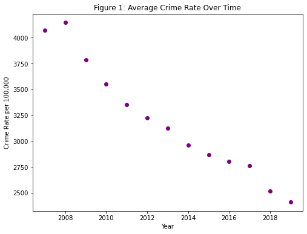

```python
plt.figure(figsize=(8, 6))
plt.scatter(crimeDF.index, crimeDF['OVERALL CRIME RATE PER 100,000 PEOPLE'], c = 'purple')
plt.xlabel('Year')
plt.ylabel('Crime Rate per 100,000')
plt.title('Figure 1: Average Crime Rate Over Time')
plt.show()
```

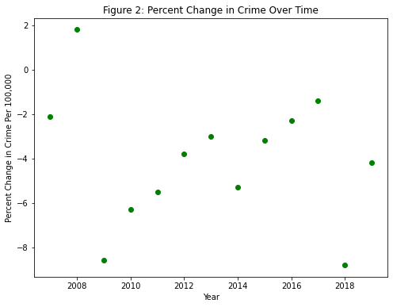

```python
plt.figure(figsize=(8, 6))
plt.scatter(crimePercentDF.index, crimePercentDF['OVERALL PERCENT CHANGE PER 100,000 PEOPLE'], c = 'green')
plt.xlabel('Year')
plt.ylabel('Percent Change in Crime Per 100,000')
plt.title('Figure 2: Percent Change in Crime Over Time')
plt.show()
```

#### Analysis

The two categories of the crime dataset being analyzed above concern the average crime rate over time and the percent change in crime rate over time. Upon further analysis, it becomes clear that both Figure 1 and Figure 2 describe similar overall trends.

Figure 1, displaying crime rate between the years 2007 to 2019, shows an overall decreasing trend. The crime rate appears slightly increase to a peak crime rate in 2008 and then gradually decreases. Figure 2 concerns the percent change in crime over time. A positive value indicates an increase in crime rate compared to the previous year while a negative value indicates a decrease in crime rate compared to the previous year. The year 2008 sees the only significant instance of an increase in crime percentage in Maryland from 2007-to 2019. While there are instances where the percentage change is closer to zero (indicating little change as compared to the previous year) there are no other instances of a positive change.

In both graphs, it can be seen that, overall, crime rates have steadily decreased in Maryland after peaking in 2008. It is possible that this peak in crime rates can be attributed to economic issues in the midst of the 2008 financial recession, a potential factor that will be analyzed more in the upcoming sections of this tutorial.

## Employment Dataset Analysis

### Unemployment Rate Over Time

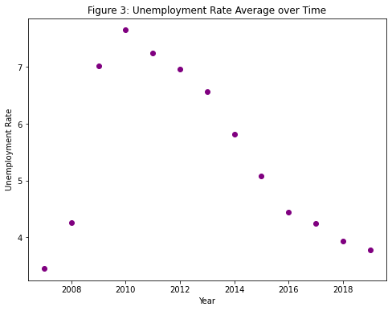

```python
plt.figure(figsize=(8, 6))
plt.scatter(employmentNew.index, employmentNew['UnemploymentRateAverage'], c = 'purple')
plt.xlabel('Year')
plt.ylabel('Unemployment Rate')
plt.title('Figure 3: Unemployment Rate Average over Time')
plt.show()
```

### Variance of Unemployment Over Time

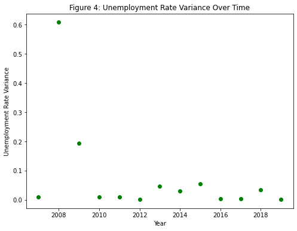

```python
plt.figure(figsize=(8, 6))
plt.scatter(employmentNew.index, employmentNew['UnemploymentRateVariance'], c = 'green')
plt.xlabel('Year')
plt.ylabel('Unemployment Rate Variance')
plt.title('Figure 4: Unemployment Rate Variance Over Time')
plt.show()
```

## Side by Side Comparison of Crime Rate and Unemployment Rate Over Time

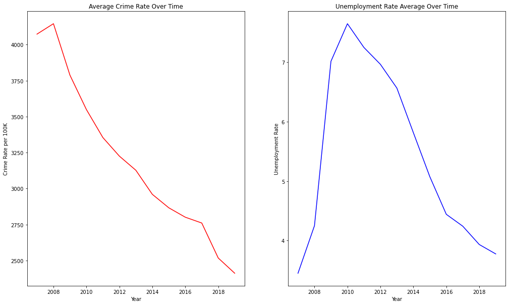

```python
plt.figure(figsize=(17, 10))

# Plot 1: Crime
plt.subplot(1, 2, 1)
plt.plot(crimeDF.index, crimeDF['OVERALL CRIME RATE PER 100,000 PEOPLE'], c = 'red')
plt.title('Average Crime Rate Over Time')
plt.xlabel('Year')
plt.ylabel('Crime Rate per 100K')

# Plot 2: Unemployment
plt.subplot(1, 2, 2)
plt.plot(employmentNew.index, employmentNew['UnemploymentRateAverage'], c = 'blue')
plt.title('Unemployment Rate Average Over Time')
plt.xlabel('Year')
plt.ylabel('Unemployment Rate')

plt.show()
```

### Further Analysis of Unemployment Rate and Crime Rate Statistics

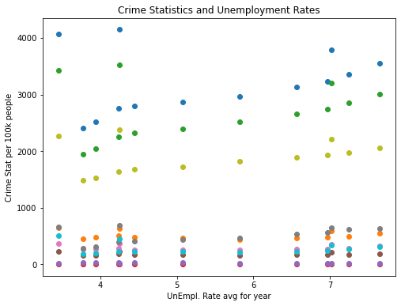

```python
plt.figure(figsize=(8, 6))
for col in crimeDF.columns:
  plt.scatter(x=employmentNew["UnemploymentRateAverage"],y=crimeDF[col])
plt.ylabel("Crime Stat per 100k people")
plt.xlabel("UnEmpl. Rate avg for year")
plt.title('Crime Statistics and Unemployment Rates')
plt.show()
```

### Further Analysis of Unemployment Rate Variance and Crime Rate Statistics

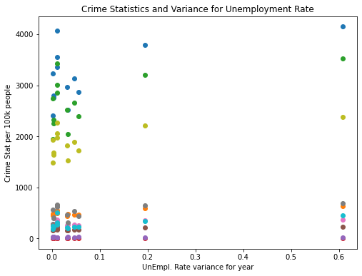

```python
plt.figure(figsize=(8, 6))
for col in crimeDF.columns:
  plt.scatter(x=employmentNew["UnemploymentRateVariance"],y=crimeDF[col])
plt.ylabel("Crime Stat per 100k people")
plt.xlabel("UnEmpl. Rate variance for year")
plt.title('Crime Statistics and Variance for Unemployment Rate')
plt.show()
```

# Hypothesis Testing

## Crime and Unemployment Rate Relational Analysis

### Linear Regression Model for Crime and Unemployment Rate

```
Coefficient of Determination: 0.05448340054419876
Intercept: [2729.79083228]
Slope: [[86.55020133]]
```

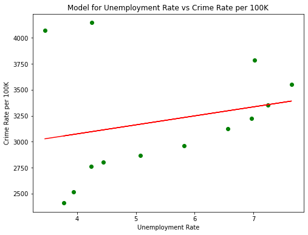

```python
x = employmentNew['UnemploymentRateAverage'].to_numpy()
y = crimeDF['OVERALL CRIME RATE PER 100,000 PEOPLE'].to_numpy()

x = x.reshape(-1,1)
y = y.reshape(-1,1)

lm = linear_model.LinearRegression()
model = lm.fit(x,y)
r_sq = lm.score(x, y)

print('Coefficient of Determination:', r_sq)
print('Intercept:', lm.intercept_)
print('Slope:', lm.coef_)
print('\n')

plt.figure(figsize=(8, 6))
Y_pred = lm.predict(x)  # make predictions
plt.scatter(x, y, c = 'green')
plt.plot(x, Y_pred, color='red')
plt.title('Model for Unemployment Rate vs Crime Rate per 100K')
plt.xlabel('Unemployment Rate')
plt.ylabel('Crime Rate per 100K')
plt.show()
```

### Ordinary Least Squares Regression for Crime and Unemployment Rate

```python
y_train = employmentNew['UnemploymentRateAverage']
x_train = crimeDF['OVERALL CRIME RATE PER 100,000 PEOPLE']
lr = sm.OLS(x_train, y_train).fit()
print(lr.summary())
```

```
                                          OLS Regression Results
==========================================================================================================
Dep. Variable:     OVERALL CRIME RATE PER 100,000 PEOPLE   R-squared (uncentered):                   0.927
Model:                                               OLS   Adj. R-squared (uncentered):              0.920
Method:                                    Least Squares   F-statistic:                              151.5
Date:                                   Mon, 16 May 2022   Prob (F-statistic):                    3.65e-08
Time:                                           09:48:32   Log-Likelihood:                         -106.57
No. Observations:                                     13   AIC:                                      215.1
Df Residuals:                                         12   BIC:                                      215.7
Df Model:                                              1
Covariance Type:                               nonrobust
===========================================================================================
                              coef    std err          t      P>|t|      [0.025      0.975]
-------------------------------------------------------------------------------------------
UnemploymentRateAverage   556.6779     45.230     12.308      0.000     458.130     655.225
==============================================================================
Omnibus:                        5.315   Durbin-Watson:                   0.435
Prob(Omnibus):                  0.070   Jarque-Bera (JB):                2.815
Skew:                           1.128   Prob(JB):                        0.245
Kurtosis:                       3.320   Cond. No.                         1.00
==============================================================================

Notes:
[1] R² is computed without centering (uncentered) since the model does not contain a constant.
[2] Standard Errors assume that the covariance matrix of the errors is correctly specified.
```

The above regression depicts a statistically significant relational model between unemployment rate and overall crime rate. At this point in the tutorial we are able to say something significant regarding the relationship between unemployment rate and average crime rate.

## Crime and Unemployment Rate Variance

### Linear Regression Model for Crime and Unemployment Rate Variance

```
Coefficient of Determination: 0.33266722510554936
Intercept: [3047.96549007]
Slope: [[1931.315375]]
```

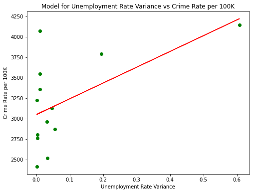

```python
x = employmentNew['UnemploymentRateVariance'].to_numpy()
y = crimeDF['OVERALL CRIME RATE PER 100,000 PEOPLE'].to_numpy()

x = x.reshape(-1,1)
y = y.reshape(-1,1)

lm = linear_model.LinearRegression()
model = lm.fit(x,y)
r_sq = lm.score(x, y)

print('Coefficient of Determination:', r_sq)
print('Intercept:', lm.intercept_)
print('Slope:', lm.coef_)
print('\n')

plt.figure(figsize=(8, 6))
Y_pred = lm.predict(x)  # make predictions
plt.scatter(x, y, c = 'green')
plt.plot(x, Y_pred, color='red')
plt.title('Model for Unemployment Rate Variance vs Crime Rate per 100K')
plt.xlabel('Unemployment Rate Variance')
plt.ylabel('Crime Rate per 100K')
plt.show()
```

### Ordinary Least Squares Regression for Crime and Unemployment Rate Variance

```python
y_train = employmentNew['UnemploymentRateVariance']
x_train = crimeDF['OVERALL CRIME RATE PER 100,000 PEOPLE']

lr = sm.OLS(x_train, y_train).fit()

print('P-value: ')
print(lr.f_pvalue)
print(lr.summary())
```

```
P-value:
0.058353415178998225
                                          OLS Regression Results
==========================================================================================================
Dep. Variable:     OVERALL CRIME RATE PER 100,000 PEOPLE   R-squared (uncentered):                   0.267
Model:                                               OLS   Adj. R-squared (uncentered):              0.206
Method:                                    Least Squares   F-statistic:                              4.377
Date:                                   Mon, 16 May 2022   Prob (F-statistic):                      0.0584
Time:                                           09:48:32   Log-Likelihood:                         -121.52
No. Observations:                                     13   AIC:                                      245.0
Df Residuals:                                         12   BIC:                                      245.6
Df Model:                                              1
Covariance Type:                               nonrobust
============================================================================================
                               coef    std err          t      P>|t|      [0.025      0.975]
--------------------------------------------------------------------------------------------
UnemploymentRateVariance  9387.9137   4487.231      2.092      0.058    -388.923    1.92e+04
==============================================================================
Omnibus:                       23.204   Durbin-Watson:                   0.460
Prob(Omnibus):                  0.000   Jarque-Bera (JB):               23.146
Skew:                          -2.220   Prob(JB):                     9.42e-06
Kurtosis:                       7.799   Cond. No.                         1.00
==============================================================================

Notes:
[1] R² is computed without centering (uncentered) since the model does not contain a constant.
[2] Standard Errors assume that the covariance matrix of the errors is correctly specified.
```

# Conclusion

Here, our exploratory analysis portion was helpful since it pointed to a potential relationship between crime rate and unemployment rate as shown in the figure below. This provided the foundation for performing a worthwhile regression analysis on these variables.

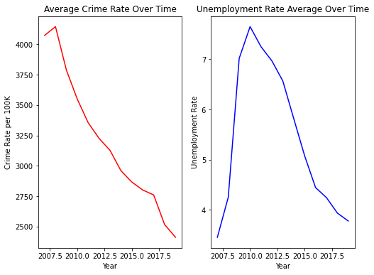

Our second regression model was the ordinary least squared regression for crime and unemployment rate variance. The analysis of variance is unique since it is a measure of spread. In this case, the variance measures the dispersion of unemployment rates. This regression yielded an r-squared value of .267, indicating that not much of the variation in the crime rate per 100,000 people can be explained by the variation in the unemployment rate variance. Our associated p-value was found to be .0584. This is greater than .05. This, coupled with our weak r-squared value, indicates that this relationship cannot be well described with this model and that, perhaps, it is not a strong relationship to analyze.

Our tutorial laid out the crucial steps of the data science process. As part of this tutorial, we obtained, parsed, and curated our data to prepare it for our analysis. Our exploratory analysis explored potential relationships that we could do a regression on. It highlighted trends in data that prompted further analysis and that could be explained by the financial situation of that period. Our final step was to do a hypothesis test. As said above, we found the relationship between crime per 100,000 to be statistically significant using the ordinary least squares approach while the association between unemployment rate variance and crime rate was not found to be significant.

It is worth noting however that all the potential relationships between our datasets concerning employment and crime were not analyzed in this tutorial and that further exploratory and subsequent regression analysis could yield surprising results.